# R Notebook

1.1 Hypothesis testing - practical

```r
library(infer)
library(tidyverse)

animal_sleep_data <- msleep
```

[output not shown]

```r
glimpse(animal_sleep_data)
```

```
Rows: 83
Columns: 11
$ name         <chr> "Cheetah", "Owl monkey", "Mountain beaver", "Greater s…
$ genus        <chr> "Acinonyx", "Aotus", "Aplodontia", "Blarina", "Bos", "…
$ vore         <chr> "carni", "omni", "herbi", "omni", "herbi", "herbi", "c…
$ order        <chr> "Carnivora", "Primates", "Rodentia", "Soricomorpha", "…
$ conservation <chr> "lc", NA, "nt", "lc", "domesticated", NA, "vu", NA, "d…
$ sleep_total  <dbl> 12.1, 17.0, 14.4, 14.9, 4.0, 14.4, 8.7, 7.0, 10.1, 3.0…
$ sleep_rem    <dbl> NA, 1.8, 2.4, 2.3, 0.7, 2.2, 1.4, NA, 2.9, NA, 0.6, 0.…
$ sleep_cycle  <dbl> NA, NA, NA, 0.1333333, 0.6666667, 0.7666667, 0.3833333…
$ awake        <dbl> 11.9, 7.0, 9.6, 9.1, 20.0, 9.6, 15.3, 17.0, 13.9, 21.0…
$ brainwt      <dbl> NA, 0.01550, NA, 0.00029, 0.42300, NA, NA, NA, 0.07000…
$ bodywt       <dbl> 50.000, 0.480, 1.350, 0.019, 600.000, 3.850, 20.490, 0…
```

```r
animal_sleep_data %>%
  summarise(across(.fns = ~sum(is.na(.x))))
```

| name | genus | vore | order | conservation | sleep_total | sleep_rem | sleep_cycle | awake | brainwt | bodywt |
| --- | --- | --- | --- | --- | --- | --- | --- | --- | --- | --- |
| 0 | 0 | 7 | 0 | 29 | 0 | 22 | 51 | 0 | 27 | 0 |

Jabberwockies sleep for around 7 hours a night, on average. Perform an appropriate statistical test to determine whether the mean sleep_total in the sampled population of animal types differs from the typical value for jabberwockies

```r
animal_sleep_data %>%
  ggplot(aes(x = sleep_total)) +
  geom_histogram(col = "white", bins = 30)
```

[output not shown]

H0 = the mean_sleep total of the sampled population will be the same as the 7 hours sleep that Jabberwockies get.

Ha = the mean_sleep total of the sampled population will be **different** to a statistically significant level that the 7 hours that Jabberwockies get.

```r
sleep_observed_stat <-
  animal_sleep_data %>%
  summarise(mean_sleep = mean(sleep_total))

sleep_observed_stat
```

[output not shown]

α = 0.05

```r
sleep_null_distribution <-
  animal_sleep_data %>%
  specify(response = sleep_total) %>%
  hypothesize(null = "point", mu = 7) %>%
  generate(reps = 5000, type = "bootstrap") %>%
  calculate (stat = "mean")
```

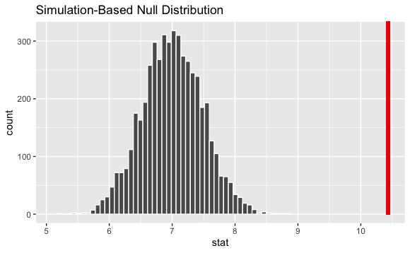

```r
sleep_null_distribution %>%
  visualise(bins = 50) +
  shade_p_value(obs_stat = sleep_observed_stat$mean_sleep, direction = "both")
```

```r
sleepy_value <- sleep_null_distribution %>%
  get_p_value(obs_stat = sleep_observed_stat$mean_sleep, direction = "both")
```

```
Please be cautious in reporting a p-value of 0. This result is an approximation based on the number of `reps` chosen in the `generate()` step. See `?get_p_value()` for more information.
```

```r
sleepy_value
```

| p_value |
| --- |
| 0 |

**Our p-value is less than our alpha value and therefore the null hypothesis is rejected in favour of our alternative hypothesis:**

**Ha = the mean_sleep total of the sampled population will be different to a statistically significant level that the 7 hours that Jabberwockies get.**

Perform an appropriate statistical test to determine whether omnivores sleep for significantly longer than herbivores, on average.

H0 = There is no statistically significant different between the average numbers of sleep for omnivores an herbivores.

Ha = Omnivores on average sleep for a statistically longer time than herbivores

H0: μavg_sleep(omnivores) − μavg_sleep(herbivores) = 0 Ha: μavg_sleep(omnivores) − μavg_sleep(herbivores) > 0

α = 0.05

```r
om_herb_hours_slept <-
  animal_sleep_data %>%
  group_by(vore) %>%
  #filter(vore == c("herbi", "omni")) %>%
  summarise(n = n())

om_herb_hours_slept
```

[output not shown]

```r
om_herb_filtered <-
  animal_sleep_data %>%
  filter(vore == c("herbi", "omni"))

head(om_herb_filtered)
```

[output not shown]

```r
om_herb_null_distribtion <-
  om_herb_filtered %>%
  specify(sleep_total ~ vore) %>%
  hypothesise(null = "independence") %>%
  generate(reps = 5000, type = "permute") %>%
  calculate(stat = "diff in means", order = c("omni", "herbi"))

head(om_herb_null_distribtion)
```

[output not shown]

```r
obs_om_herb_stat <-
  om_herb_filtered %>%
  specify(sleep_total ~ vore) %>%
  calculate(stat = "diff in means", order = c("omni", "herbi"))

obs_om_herb_stat
```

[output not shown]

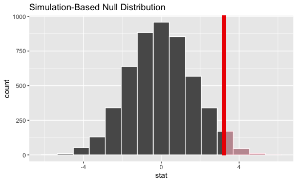

```r
om_herb_null_distribtion %>%
  visualise() +
  shade_p_value(obs_stat = obs_om_herb_stat, direction = "greater")
```

```r
om_herb_p_value <- om_herb_null_distribtion %>%
  get_p_value(obs_stat = obs_om_herb_stat, direction = "greater")

om_herb_p_value
```

| p_value |
| --- |
| 0.0298 |

**The calculate p-value is less than our alpha and therefore the null hypothesis is rejected in favour of the alternative hypothesis:**

**Ha = Omnivores on average sleep for a statistically longer time than herbivores**

Perform an appropriate statistical test to determine whether the proportion of domesticated animal types in the population of animal types is greater than 5%.

H0 = The proportion of domesticated animal types is less than or equal to 5%

Ha = The proportion of domesticated animal types is more than 5%

H0: πdomesticated_animals <= 0.05

Ha: πdomesticated_animals > 0.05

α = 0.02

```r
labeled_animal_data <-
  animal_sleep_data %>%
  filter(!is.na(conservation)) %>%
  mutate(is_domesticated = ifelse(conservation == "domesticated", "Yes", "No"))
head(labeled_animal_data)
```

[output not shown]

```r
obs_domest_stat <-
  labeled_animal_data %>%
  specify(response = is_domesticated, success = "Yes") %>%
  calculate(stat = "prop")

obs_domest_stat
```

[output not shown]

```r
domest_null_distribution <-
  labeled_animal_data %>%
  specify(response = is_domesticated, success = "Yes") %>%
  hypothesise(null = "point", p = 0.05) %>%
  generate(reps = 5000, type = "simulate") %>%
  calculate(stat = "prop")
```

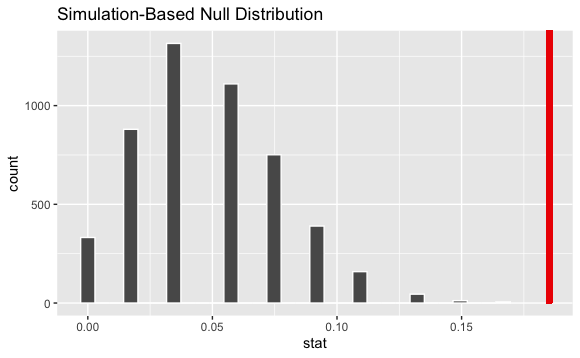

```r
domest_null_distribution %>%
  visualise(bins = 30) +
  shade_p_value(obs_stat = obs_domest_stat, direction = "greater")
```

```r
dom_p_value <- domest_null_distribution %>%
  get_p_value(obs_stat = obs_domest_stat, direction = "greater")

dom_p_value
```

[output not shown]

**The calculate p-value is less than the alpha and therefore the null hypothesis is rejected in favour of the alternative hypothesis:**

**Ha = The proportion of domesticated animal types is more than 5%**

1.2.1 Defining the Hypothesis

For the following three business problems write out H0 and Ha in both mathematical notation and in words. Also state the method you would use to generate the null distribution (bootstrap, permutation or simulation).

1. You work for a independent coffee shop. The boss tells you that she thinks that around 40% of people in the town (population 30,000) know of the coffee shop, but you are skeptical of the estimate. You conduct a random survey of 200 people in the town, asking if respondents are aware of your coffee shop. You want to use the sample to test the hypothesis that 40% or more of the town’s population have heard of the coffee shop.

**H0 = The proportion of people in the town that know of the coffee shop is 40%**

**Ha = The proportion of people in the town that know of the coffee shop is more than 40%.**

H0: πknow_about_cs = 0.4

Ha: πknow_about_c > 0.4

α = 0.05

Method: Simulation

2. You work for a website design company and have performed an A/B test on the position of a banner on a website promoting a particular item.

You selected five days at random last month and then randomly selected 200 of each sampled day’s users into group A and another 200 of that day’s users into group B. Group A continued to be shown the banner at the right hand side of the webpage (its usual position) while group B was shown the banner at the top of the page. You monitored each sampled user’s interactions with the website, in particular the ‘click through rate’ (CTR) on the banner, i.e. what proportion of sampled users clicked on the banner. You want to use the sampled data to test the hypothesis that website users overall are more likely to click on the banner if positioned at the top of the page

**H0 = The ctr of those shown the banner at the top of the screen will not be different to a statistically significant level when compared to the ctr of those shown the banner at the top of the screen**

**Ha = The ctr rate will be higher for those shown the banner at the top of the screen to a statistically significant level.**

H0: πctr_top - πctr_right = 0

Ha: πctr_top - πctr_right > 0

α = 0.01

Method: Permutation

3. You work as an analyst for a car manufacturing company - they have specific standards they must meet for standards and regulation purposes. You have been asked to check the quality control of the manufacture of a particular car part. You have been given data on a sample of 200 parts produced over the period of a week (the sampled parts were pulled at random from the production line and measured: the factory produced a lot more than 200 parts that week). The specification of the part stipulates a width of 145mm, and the manufacturing process is said to have ‘drifted’ if the mean width of parts differs significantly from 145mm. You want to use the sampled measurements to test whether the process overall has drifted.

**H0 = The population mean (of the larger number of parts produced) will not differ to a statistically significant level from 145mm**

**Ha = The population mean (of the larger number of parts produced)** will **differ to a statistically significant level from 145mm**

H0: μmean_width = 145

Ha: μmean_width ≠ 145

α = 0.05

Method: Bootstrap

1.2.2 Interpreting the results

For the 3 business problems stated above, imagine we performed you got the following p-values (with the given significance levels) write out your interpretation of the results.

1. Coffee shop problem. Significance level: 0.05, calculated p-value: 0.07

**The p-value is greater than our stated alpha value so therefore we fail to reject the null hypotesis for our experiement. In other words, we fail to reject the statement that the proporation of people that know about the coffee shop in the town is around 40%.**

2. Website company problem. Significance level: 0.01, p-value: 0.006

**The p_value is less than our set alpha value, which in itself is set to quite a strict level. This means that we reject the null hypothesis in favour of the alternative hypothesis, namely that the ctr rate will be higher for those shown the banner at the top of the screen.**

3. Manufacturing company problem. Significance level: 0.05, p-value: 0.55